# Example 3: Stepwise vs Basic Logistic regression

Author: Gurakuqi Jurgen

The dataset bank-deposit-complete.csv is an extended version of the dataset considered in the second exercise of the first part of this exam. The dataset includes 10 variables about a marketing campaign consisting in phone calls to convince clients to subscribe a bank term deposit.

Available variables:

subscribed the client subscribed the term deposit?

age;

job with levels “admin.”,“unknown”,“unemployed”,“management”,“housemaid”,“entrepreneur”,“student”, “blue-collar”,“self-employed”,“retired”,“technician”,“services”;

marital status with levels “married”,“divorced”,“single” (“divorced” includes widowed);

education with levels “unknown”,“primary”, “secondary”,“tertiary”;

default credit in default?

balance average yearly balance, in euros;

loan current personal loans?

contact type with levels “unknown”,“telephone”,“cellular”;

compaign number of contacts.

Which variables are most important to identify the clients who subscribes the bank term deposit? Discuss the results.

First of all, read the data and print the first 6 rows to get an idea of how the dataset is populated:

```r
bankDeposit <- read.csv("bank-deposit-complete.csv")
head(bankDeposit)
```

```
##   subscribed age         job marital education default balance loan  contact
## 1      FALSE  30  unemployed married   primary      no    1787   no cellular
## 2      FALSE  33    services married secondary      no    4789  yes cellular
## 3      FALSE  35  management  single  tertiary      no    1350   no cellular
## 4      FALSE  30  management married  tertiary      no    1476  yes  unknown
## 5      FALSE  59 blue-collar married secondary      no       0   no  unknown
## 6      FALSE  35  management  single  tertiary      no     747   no cellular
##   campaign
## 1        1
## 2        1
## 3        1
## 4        4
## 5        1
## 6        2
```

```r
summary(bankDeposit)
```

```
##  subscribed           age            job              marital
##  Mode :logical   Min.   :19.00   Length:4521        Length:4521
##  FALSE:4000      1st Qu.:33.00   Class :character   Class :character
##  TRUE :521       Median :39.00   Mode  :character   Mode  :character
##                  Mean   :41.17
##                  3rd Qu.:49.00
##                  Max.   :87.00
##   education           default             balance          loan
##  Length:4521        Length:4521        Min.   :-3313   Length:4521
##  Class :character   Class :character   1st Qu.:   69   Class :character
##  Mode  :character   Mode  :character   Median :  444   Mode  :character
##                                        Mean   : 1423
##                                        3rd Qu.: 1480
##                                        Max.   :71188
##    contact             campaign
##  Length:4521        Min.   : 1.000
##  Class :character   1st Qu.: 1.000
##  Mode  :character   Median : 2.000
##                     Mean   : 2.794
##                     3rd Qu.: 3.000
##                     Max.   :50.000
```

We observed that there are categorical variables, so we transform them into factors:

```r
bankDeposit$subscribed <- factor(bankDeposit$subscribed)
bankDeposit$job <- factor(bankDeposit$job)
bankDeposit$default <- factor(bankDeposit$default)
bankDeposit$education <- factor(bankDeposit$education)
bankDeposit$loan <- factor(bankDeposit$loan)
bankDeposit$contact <- factor(bankDeposit$contact)
bankDeposit$marital <- factor(bankDeposit$marital)
summary(bankDeposit)
```

```
##  subscribed        age                 job          marital
##  FALSE:4000   Min.   :19.00   management :969   divorced: 528
##  TRUE : 521   1st Qu.:33.00   blue-collar:946   married :2797
##               Median :39.00   technician :768   single  :1196
##               Mean   :41.17   admin.     :478
##               3rd Qu.:49.00   services   :417
##               Max.   :87.00   retired    :230
##                               (Other)    :713
##      education    default       balance       loan           contact
##  primary  : 678   no :4445   Min.   :-3313   no :3830   cellular :2896
##  secondary:2306   yes:  76   1st Qu.:   69   yes: 691   telephone: 301
##  tertiary :1350              Median :  444              unknown  :1324
##  unknown  : 187              Mean   : 1423
##                              3rd Qu.: 1480
##                              Max.   :71188
##
##     campaign
##  Min.   : 1.000
##  1st Qu.: 1.000
##  Median : 2.000
##  Mean   : 2.794
##  3rd Qu.: 3.000
##  Max.   :50.000
##
```

In order to identify the most important predictors of subscribed we can consider a logistic regression with a lasso penalty:

```r
library("glmnet")
library("glmnetUtils")
```

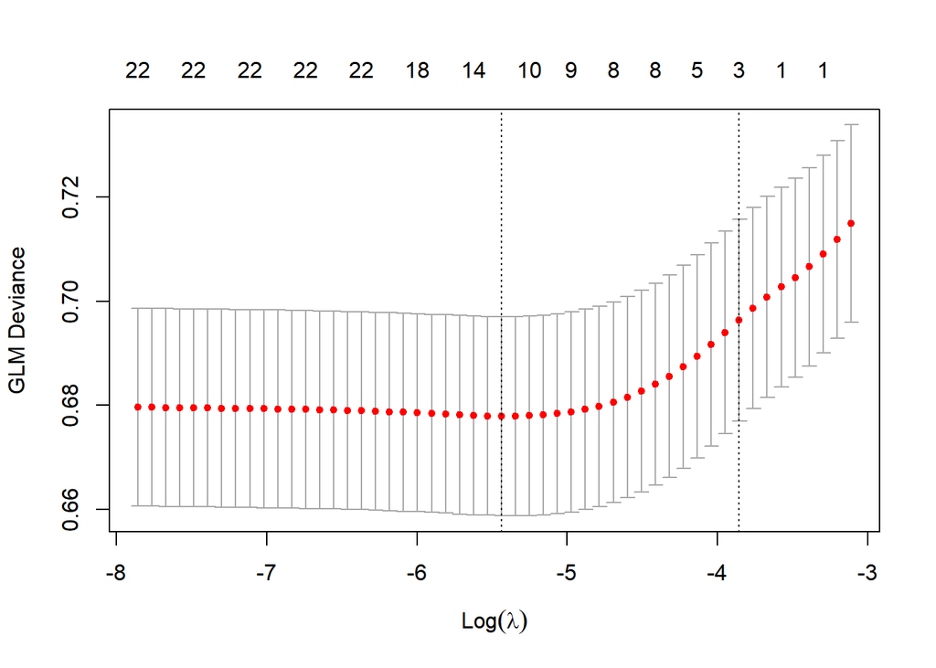

```r
set.seed(999)
mod1 <- cv.glmnet(subscribed ~ ., family = binomial,
                  data = bankDeposit)
plot(mod1)
```

```r
coef(mod1, mod1$lambda.min)
```

```
## 30 x 1 sparse Matrix of class "dgCMatrix"
##                             s1
## (Intercept)        -2.23950498
## age                 0.00485335
## jobadmin.           .
## jobblue-collar     -0.14723877
## jobentrepreneur     .
## jobhousemaid        .
## jobmanagement       .
## jobretired          0.65326730
## jobself-employed    .
## jobservices         .
## jobstudent          0.40904293
## jobtechnician       .
## jobunemployed       .
## jobunknown          0.16337214
## maritaldivorced     .
## maritalmarried     -0.29289879
## maritalsingle       .
## educationprimary    .
## educationsecondary  .
## educationtertiary   0.15737621
## educationunknown    .
## defaultno           .
## defaultyes          .
## balance             .
## loanno              0.54102279
## loanyes             .
## contactcellular     .
## contacttelephone    .
## contactunknown     -1.00222428
## campaign           -0.06372018
```

```r
coef(mod1, mod1$lambda.1se)
```

```
## 30 x 1 sparse Matrix of class "dgCMatrix"
##                             s1
## (Intercept)        -1.94515560
## age                 .
## jobadmin.           .
## jobblue-collar      .
## jobentrepreneur     .
## jobhousemaid        .
## jobmanagement       .
## jobretired          0.21145342
## jobself-employed    .
## jobservices         .
## jobstudent          .
## jobtechnician       .
## jobunemployed       .
## jobunknown          .
## maritaldivorced     .
## maritalmarried      .
## maritalsingle       .
## educationprimary    .
## educationsecondary  .
## educationtertiary   .
## educationunknown    .
## defaultno           .
## defaultyes          .
## balance             .
## loanno              0.03929927
## loanyes             .
## contactcellular     .
## contacttelephone    .
## contactunknown     -0.55272595
## campaign            .
```

The penalty that minimizes the cross-validation error and the 1-standard error from the minimum agree that the important predictors of *subscribed* are:

- job (for the retired value), with a positive relation.
- loan, with a positive relation for no and a negative one for yes.
- contact (for the unknow value), with a negative relation.

Another selection approach which we can consider to confirm the above results is the stepwise regression (with biderectional elimination):

```r
null.model <- glm(subscribed ~ 1, family = binomial,
                  data = bankDeposit)
full.model <- glm(subscribed ~ ., family = binomial,
                  data = bankDeposit)
step.model <- step(null.model, scope = list(upper = formula(full.model)),
                   direction = "both")
```

```
## Start:  AIC=3233
## subscribed ~ 1
##
##             Df Deviance    AIC
## + contact    2   3128.6 3134.6
## + job       11   3168.4 3192.4
## + loan       1   3205.2 3209.2
## + campaign   1   3208.5 3212.5
## + marital    2   3212.4 3218.4
## + education  3   3216.2 3224.2
## + age        1   3222.0 3226.0
## <none>           3231.0 3233.0
## + balance    1   3229.7 3233.7
## + default    1   3231.0 3235.0
##
## Step:  AIC=3134.62
## subscribed ~ contact
##
##             Df Deviance    AIC
## + loan       1   3101.9 3109.9
## + job       11   3084.3 3112.3
## + campaign   1   3105.4 3113.4
## + marital    2   3111.9 3121.9
## + age        1   3121.5 3129.5
## + education  3   3121.8 3133.8
## <none>           3128.6 3134.6
## + balance    1   3127.7 3135.7
## + default    1   3128.6 3136.6
## - contact    2   3231.0 3233.0
##
## Step:  AIC=3109.88
## subscribed ~ contact + loan
##
##             Df Deviance    AIC
## + campaign   1   3079.7 3089.7
## + job       11   3061.7 3091.7
## + marital    2   3086.1 3098.1
## + age        1   3095.0 3105.0
## <none>           3101.9 3109.9
## + education  3   3096.2 3110.2
```

[output cut: 49 more lines]

```
##
## Step:  AIC=3062.78
## subscribed ~ contact + loan + campaign + job + marital + age
##
##             Df Deviance    AIC
## <none>           3024.8 3062.8
## - age        1   3027.1 3063.1
## + education  3   3020.2 3064.2
## + default    1   3024.5 3064.5
## + balance    1   3024.8 3064.8
## - job       11   3051.3 3067.3
## - marital    2   3040.1 3074.1
## - campaign   1   3044.7 3080.7
## - loan       1   3046.0 3082.0
## - contact    2   3107.4 3141.4
```

```r
summary(step.model)
```

```
##
## Call:
## glm(formula = subscribed ~ contact + loan + campaign + job +
##     marital + age, family = binomial, data = bankDeposit)
##
## Coefficients:
##                   Estimate Std. Error z value Pr(>|z|)
## (Intercept)      -1.525893   0.316794  -4.817 1.46e-06 ***
## contacttelephone -0.082570   0.180714  -0.457  0.64774
## contactunknown   -1.164803   0.143565  -8.113 4.92e-16 ***
## loanyes          -0.713803   0.167594  -4.259 2.05e-05 ***
## campaign         -0.094393   0.023882  -3.952 7.73e-05 ***
## jobblue-collar   -0.363980   0.191959  -1.896  0.05794 .
## jobentrepreneur  -0.210463   0.310039  -0.679  0.49725
## jobhousemaid      0.008310   0.325387   0.026  0.97962
## jobmanagement     0.066467   0.171867   0.387  0.69895
## jobretired        0.586495   0.246247   2.382  0.01723 *
## jobself-employed  0.001207   0.280717   0.004  0.99657
## jobservices      -0.219470   0.224329  -0.978  0.32791
## jobstudent        0.505010   0.311220   1.623  0.10466
## jobtechnician    -0.161100   0.185099  -0.870  0.38411
## jobunemployed    -0.311689   0.329820  -0.945  0.34464
## jobunknown        0.425707   0.451145   0.944  0.34537
## maritalmarried   -0.426974   0.143785  -2.970  0.00298 **
## maritalsingle    -0.039822   0.166939  -0.239  0.81146
## age               0.008714   0.005718   1.524  0.12750
## ---
## Signif. codes:  0 '***' 0.001 '**' 0.01 '*' 0.05 '.' 0.1 ' ' 1
##
## (Dispersion parameter for binomial family taken to be 1)
##
##     Null deviance: 3231.0  on 4520  degrees of freedom
## Residual deviance: 3024.8  on 4502  degrees of freedom
## AIC: 3062.8
##
## Number of Fisher Scoring iterations: 5
```

According to stepwise regression:

- **contact** (for unknown) is *strongly* significant, and *negatively* related to the subscribed response.
- **loan** is *strongly* significant, and *negatively* related to the response.
- **campaign** is *strongly* significant, and *negatively* related to the response.
- **job** (for retired) is *weakly* significant, and *positively* related to the response.
- **marital** (for married) is significant, and *negatively* related to the response.
- Age, and any other value not expressed for the considered predictors are not significant.
- The $AIC$ is *3062.8*.

We could also compare the two model which are obtained using the two different sets of predictor through a 10-fold cross validation

```r
glm.fit <- glm(subscribed ~ job + loan + contact, data = bankDeposit, family = binomial)

library(boot)
cv.glm(bankDeposit, glm.fit, K = 10)$delta
```

```
## [1] 0.09904178 0.09899907
```

```r
cv.glm(bankDeposit, step.model, K = 10)$delta
```

```
## [1] 0.09851828 0.09844994
```

As we can see, the resiults are very similar, but the set obtained through stepwise regression seems lightly better, so we pick its set of predictors as best predictors of subscribed.